# Definitions

[output not shown]

## Initialization of Variables

```python
%matplotlib inline

import pandas as pd
import matplotlib.pyplot as plt
import pandas.io.data as web
import scipy.linalg as blas
import numpy as np
import datetime as dt

#--------------------------------
#Configuration
#--------------------------------
date_start = dt.date(2010, 1, 1)
date_end = dt.date(2010, 2, 1)

ticker = ['XBB.TO', 'SPY']
risk_free_rate = 0
target_returns = []

#--------------------------------
# Download Data
#--------------------------------

# # try to download the data
# try:
#     f = web.DataReader(ticker, 'yahoo', date_start, date_end)

#     # Select Adj Close and compute percentage change
#     data = f['Adj Close']

# # if an error occur load offline data
# except:
data = pd.read_csv("c:/Users/pastafarian/Dropbox/project/variance_min/test.csv")

start = 600
window = 100
data = pd.DataFrame(data.values[start:start + window, :])

# returns and covariance
returns = np.log(data/data.shift(1))
expected_returns = returns.mean()
covariance = returns.cov()
maxx = 0
minn = 0

maxx = max(expected_returns)
minn = min(expected_returns)
rng = 20;
step = (maxx - minn) / float(rng - 1)

if len(target_returns) == 0:
    target_returns = [ minn + i * step for i in range(0, rng)]

n = len(ticker)
m = len(target_returns)

# define helper function to compute variance and returns
def portfolio_variance(weight):
    w = weight[0:n]    # this step make sure w has the right size to handle
                            # the case were weight include the risk free weight
    return np.transpose(w).dot(covariance).dot(w)

def portfolio_return(weight, rf=0.0):
    """ Return the expected portfolio return given the weight"""
    w = weight[0:n]     # this step make sure w has the right size to handle
                        # the case were weight include the risk free weight
    if rf != 0:
        return np.transpose(w).dot(expected_returns) + rf * weight[n]
    else:
        return np.transpose(w).dot(expected_returns)
```

# Equation System

$\begin{eqnarray*} L(W, \lambda_{1}) & = & \frac{1}{2}W_{1 \times n}^{T} \Sigma_{n \times n} W_{n \times 1} - \lambda_{1} ( e_{1 \times n} W_{n \times 1} - 1) \\ \\ \frac{\partial L(W, \lambda_{1})}{\partial W}& = & W_{1 \times n}^{T} \Sigma_{n \times n} - \lambda_{1} e_{1 \times n} = 0\\ \frac{\partial L(W, \lambda_{1})}{\partial \lambda_1} & = & - e_{1 \times n} W_{n \times 1} + 1 = 0\\ \end{eqnarray*}$

## Matrix Form

### Minimal Variance (No Risk Free rate and no target return)

$\begin{equation*} \begin{bmatrix} \Sigma && - e \\ e^{T} && 0 \\ \end{bmatrix} \begin{bmatrix} x \\ \lambda_{1} \\ \end{bmatrix}=\begin{bmatrix} 0 \\ 1 \\ \end{bmatrix} \end{equation*}$

```python
def min_var():
    A = np.zeros((n + 1, n + 1))
    A[0:n, 0:n] = covariance
    A[n, 0:n] = + np.ones(n)
    A[0:n, n] = - np.ones(n)

    B = np.zeros((n + 1, 1))
    B[n] = 1

    # we save the weights
    return blas.solve(A, B)[0:n, 0]

variance_min = min_var()

std_min = np.sqrt(portfolio_variance(variance_min)) * 100
ret_min = portfolio_return(variance_min)
```

### Efficient Frontier (No Risk Free rate and target return)

$\begin{equation*} \begin{bmatrix} \Sigma && - e && - R \\ e^{T} && 0 && 0 \\ R^{T} && 0 && 0 \end{bmatrix} \begin{bmatrix} x \\ \lambda_{1} \\ \lambda_{2} \\ \end{bmatrix}=\begin{bmatrix} 0 \\ 1 \\ r_{t} \end{bmatrix} \end{equation*}$

```python
def efficient_frontier():
    A = np.zeros((n + 2, n + 2))
    A[0:n, 0:n] = covariance

    A[n, 0:n] = + np.ones(n)
    A[0:n, n] = - np.ones(n)

    A[n + 1, 0:n] = + expected_returns.values
    A[0:n, n + 1] = - expected_returns.values

    B = np.zeros((n + 2, m))
    B[n, 0:m] = np.ones(m)
    B[n + 1, 0:m] = target_returns

    return blas.solve(A, B)[0:n, 0:m]

efficient_portfolio = efficient_frontier()
```

### Graphics

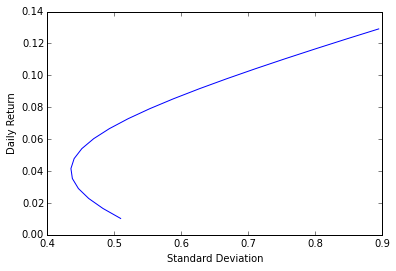

```python
std_eff = [100 * np.sqrt(portfolio_variance(efficient_portfolio[:, i])) for i in range(0, rng)]

efficient_frontier = plt.figure()
ax = efficient_frontier.add_subplot(111)
ax.axes.xaxis.set_label_text('Standard Deviation')
ax.axes.yaxis.set_label_text('Daily Return')

ax.plot(std_eff, np.array(target_returns) * 100, label='Efficient Frontier')
```

### Capital Allocation Line (Risk Free rate and target return)

$\begin{equation*} \begin{bmatrix} \Sigma && 0 && - e && - R \\ 0 && 0 && - 1 && - rf \\ e^{T} && 1 && 0 && 0 \\ R^{T} && rf && 0 && 0 \end{bmatrix} \begin{bmatrix} W \\ w_{rf} \\ \lambda_{1} \\ \lambda_{2} \\ \end{bmatrix}=\begin{bmatrix} 0 \\ 0 \\ 1 \\ r_{t} \end{bmatrix} \end{equation*}$

```python
def capital_allocation_line():
    m = len(target_returns)

    A = np.zeros((n + 3, n + 3))
    A[0:n, 0:n] = covariance

    A[n + 1, 0:n + 1] = + np.ones(n + 1)
    A[0:n + 1, n + 1] = - np.ones( + 1)

    A[n + 2, 0:n] = + expected_returns.values
    A[0:n, n + 2] = - expected_returns.values

    A[n + 2, n] = + risk_free_rate
    A[n, n + 2] = - risk_free_rate

    B = np.zeros((n + 3, m))
    B[n + 1, 0:m] = np.ones(m)
    B[n + 2, 0:m] = target_returns

    return blas.solve(A, B)[0:n + 1, 0:m]

cal = capital_allocation_line()
```

### Graphics

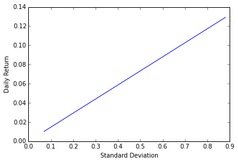

```python
std_cal = [100 * np.sqrt(portfolio_variance(cal[:, i])) for i in range(0, rng)]

cal_graph = plt.figure()
ax = cal_graph.add_subplot(111)
ax.axes.xaxis.set_label_text('Standard Deviation')
ax.axes.yaxis.set_label_text('Daily Return')

ax.plot(std_cal, np.array(target_returns) * 100, label='Capital Allocation Line')
```

## Summary

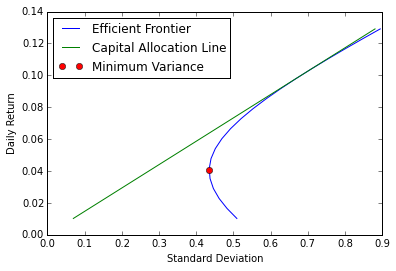

```python
sum_graph = plt.figure()
ax = sum_graph.add_subplot(111)
ax.axes.xaxis.set_label_text('Standard Deviation')
ax.axes.yaxis.set_label_text('Daily Return')

ax.plot(std_eff, np.array(target_returns) * 100, label='Efficient Frontier')
ax.plot(std_cal, np.array(target_returns) * 100, label='Capital Allocation Line')
ax.plot(std_min, ret_min * 100, 'o', label='Minimum Variance')

ax.legend(loc=2)
```

### Optimal Portfolio

```python
# first we need to estimate the parameters of the call
b = risk_free_rate
a = (target_returns[0] - target_returns[1]) / (std_cal[0] - std_cal[1])
```

```python
def std(w):
    return np.sqrt(w.dot(covariance).dot(np.transpose(w)))

def optimal_portfolio():
    weight = variance_min
    weight = blas.solve(covariance, expected_returns * (std(weight) / a))
    return weight / sum(weight)

optimal = np.zeros(n + 1)
optimal[0:n] = optimal_portfolio()
```

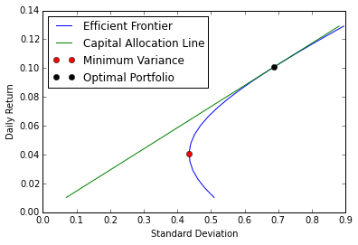

```python
std_opt = np.sqrt(portfolio_variance(optimal)) * 100
ret_opt = portfolio_return(optimal)

sum_graph = plt.figure()
ax = sum_graph.add_subplot(111)
ax.axes.xaxis.set_label_text('Standard Deviation')
ax.axes.yaxis.set_label_text('Daily Return')

ax.plot(std_eff, np.array(target_returns) * 100, label='Efficient Frontier')
ax.plot(std_cal, np.array(target_returns) * 100, label='Capital Allocation Line')
ax.plot(std_min, ret_min * 100, 'o', label='Minimum Variance')
ax.plot(std_opt , ret_opt * 100, 'ok', label='Optimal Portfolio')

ax.legend(loc=2)
```